# Report MS

```r
load( paste0("RData/temporal",Data,".RData") )
load("RData/Feature.RData")

## Counting relapses
rel = grep(pattern = "RELAPSES", colnames(Feature))
temporalCurve$NumberRelapses = 0

for( i in unique(temporalCurve$ID)){
  temporalCurve[which(temporalCurve$ID == i),"NumberRelapses"] =
    length(
      Feature[which(Feature$ID == i)[1],rel][!is.na(Feature[which(Feature$ID == i)[1],rel] )]
    )
}

temporalCurve = temporalCurve %>%
  mutate(Relapses = ifelse(NumberRelapses ==0, "No rel","At least one"))
temporalCurve$TypeRel = sapply(1:length(temporalCurve[,1]),
                               function(x) gsub(pattern = "NA",replacement = "",paste(Feature[x,rel],collapse = "")) )

temporalCurve$NumberRelapses = as.factor(temporalCurve$NumberRelapses)
#####

#patientsToNotConsider = c("CA0001","PR0002", "PR0004","ZG0005", "ZG0010", "ZG0017")

patientsToNotConsider = c("PR0002", "PR0004","ZG0005", "ZG0010", "ZG0017")

TemporalCurve = merge(temporalCurve,
                      Feature, by = "ID")

TemporalCurve$Exp = Data

rel = grep(pattern = "RELAPSES", colnames(TemporalCurve))

do.call(rbind,
        lapply(temporalCurve %>%
                 filter(Relapses!="No rel") %>%
                 dplyr::select(ID) %>%
                 distinct() %>%
                 unlist(),
               function(i){
                 TemporalCurve_sub = TemporalCurve %>%
                   filter(ID == i)

                 ftime = gsub(pattern = "M",
                              replacement = "",
                              x = TemporalCurve_sub[1,rel][!is.na(TemporalCurve_sub[1,rel] )]
                 )
                 ftime = unlist( strsplit(x = ftime,split = ",") )
                 ftime = min(as.numeric(ftime))

                 TemporalCurve_sub = TemporalCurve_sub %>%
                   dplyr::select(ID,Time, Exp) %>%
                   na.omit() %>%
                   dplyr::group_by(Exp) %>%
                   dplyr::mutate(dif = Time - ftime ) %>%
                   filter(dif > 0)  %>%
                   filter(dif == min(dif)) %>%
                   ungroup() %>%
                   dplyr::select(-dif) %>%
                   rename(TimeAfterFirstRel = Time)

                 TemporalCurve_sub$FirstRel = ftime
                 return(TemporalCurve_sub)
               })
) -> firstRelapse

Feature = merge(Feature,
                firstRelapse,all.x = T)

Feature$Exp = Data

temporalCurve =
  temporalCurve %>%
  dplyr::select(ID,Time, Observation) %>%
  filter(! ID %in% patientsToNotConsider) %>%
  group_by(ID) %>%
  na.omit() %>%
  mutate(l = length(ID)) %>%
  filter(l>2) %>%
  select(-l) %>%
  ungroup()

Feature = Feature %>% filter(! ID %in% patientsToNotConsider)

temporalCurve$Observation = as.numeric(temporalCurve$Observation)

# remove time after third injection
temporalCurve = temporalCurve %>% filter( !(ID == "CA0001" & Time == 72) )

CONNECTORList = DataFrameImport(TimeSeriesDataFrame = as.data.frame(temporalCurve) %>%
                                  dplyr::select(ID,Observation,Time),
                                AnnotationFrame = as.data.frame(Feature) )
```

Summary

Number of curves: 21 ; Min curve length: 3 ; Max curve length: 9 . ###############################

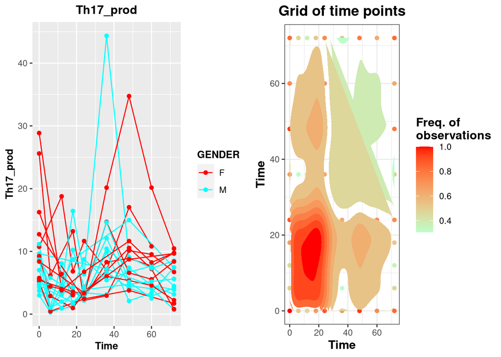

```r
### Visualization

Datavisual<-DataVisualization(CONNECTORList,
                              feature="GENDER",
                              labels = c("Time",Data,Data))

Datavisual
```

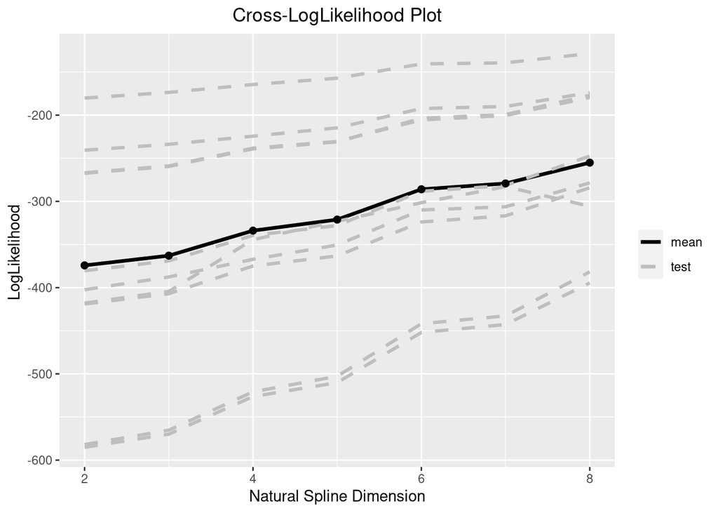

```r
### Calculation of p
CrossLogLike<-BasisDimension.Choice(CONNECTORList,2:8,Cores = 10)

CrossLogLike$CrossLogLikePlot
```

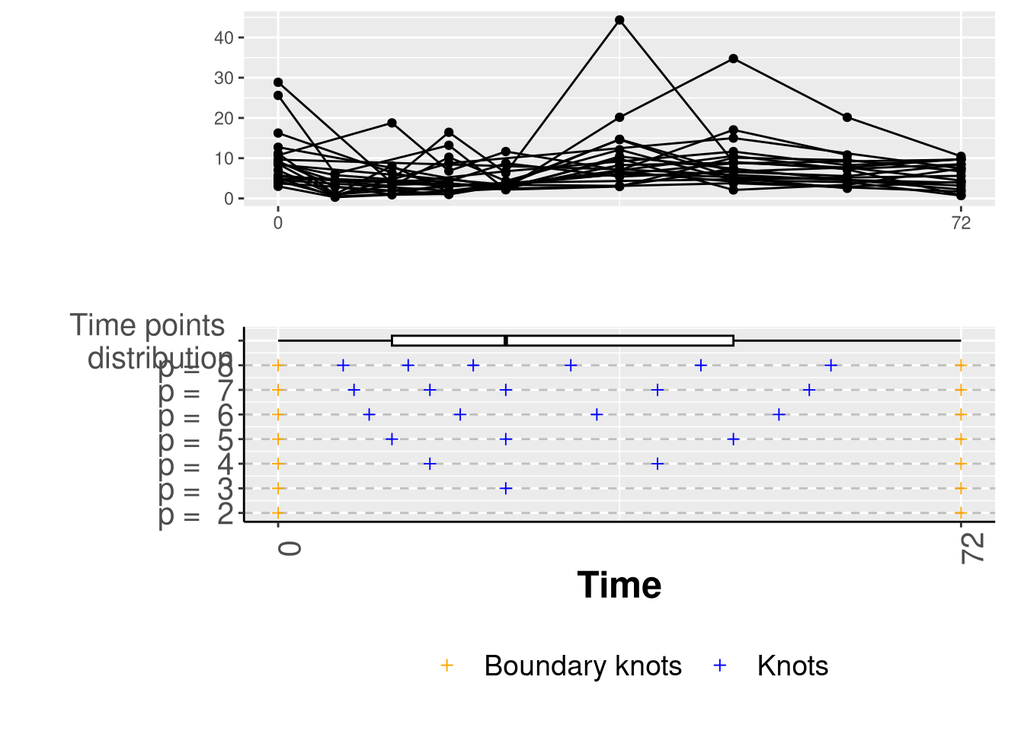

```r
CrossLogLike$KnotsPlot
```

```r
file = paste0("RData/Cluster",Data,"_p",p,".RData")
if(file.exists(file)){
  load(file)
}else{
  S.cl <-ClusterAnalysis(CONNECTORList,
                         G=2:7,
                         p=p,
                         runs=200,
                         Cores=20)
  save(S.cl, file = file)
}


IndexesPlot.Extrapolation(S.cl,q = 0.0)-> indexes
```

[1] “Cluster 7 has the following errors: All runs have errors, that are the following:ERROR in prediction: number of clusters obtained is different from 7”

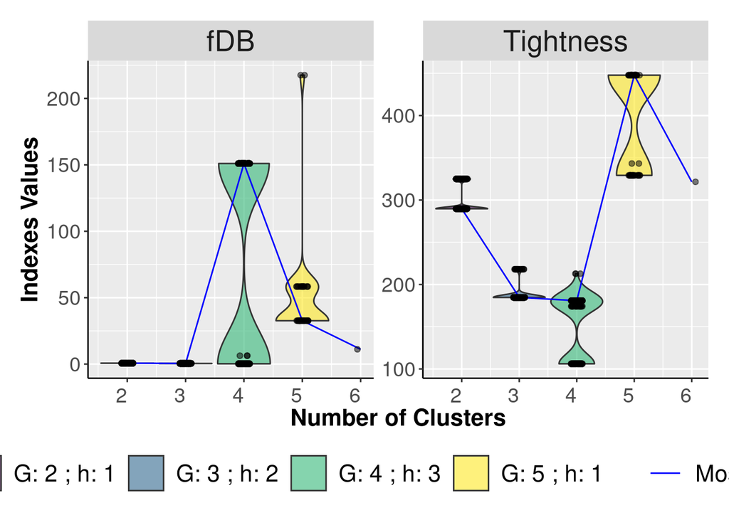

```r
indexes$Plot
```

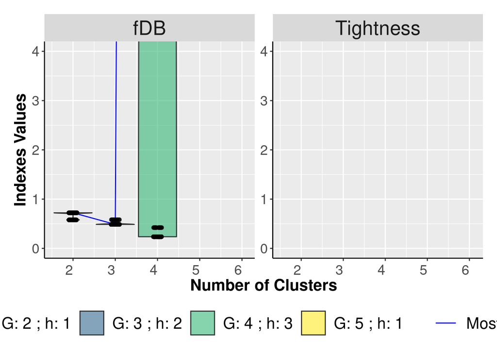

```r
indexes$Plot +
  coord_cartesian(ylim=c(0, 4))
```

```r
ConsMatrix.Extrapolation(S.cl)-> ConsInfo
```

[1] “Cluster 7 has the following errors: All runs have errors, that are the following:ERROR in prediction: number of clusters obtained is different from 7”

```r
for(G in g){
  cat( paste0("\n## G = ",G, "##") )
  print(ConsInfo[[paste0("G",G)]]$ConsensusPlot)

  MostProbableClustering.Extrapolation(S.cl,G,q = .0) ->MostProbableClustering

  FCMplots<- ClusterWithMeanCurve(clusterdata = MostProbableClustering,
                                  feature="GENDER",
                                  labels = c("Time",Data))

  ### Disriminant Plot (goodness of the cluster)
  DSpl = DiscriminantPlot(clusterdata = MostProbableClustering,
                          feature = "GENDER")

  print(DSpl[[1]])
}
```

## G = 2## [1] “Cluster 7 has the following errors: All runs have errors, that are the following:ERROR in prediction: number of clusters obtained is different from 7”

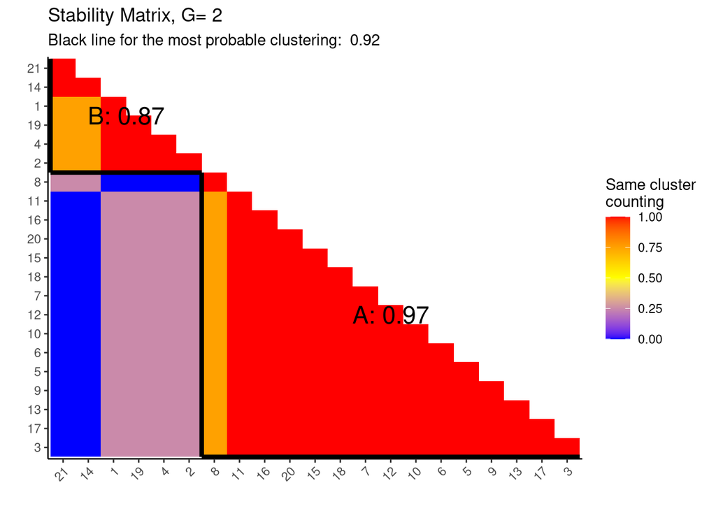

S indexes

|  | S | S_1 | S_2 |
| --- | --- | --- | --- |
| Cluster A | 8.423523 | 0.6522057 | 0.0801422 |
| Cluster B | 31.725194 | 2.8378870 | 0.3276823 |

```
    ######## M indexes ############
```

|  | Cluster A | Cluster B |
| --- | --- | --- |
| Cluster A | 0.000 | 55.624 |
| Cluster B | 55.624 | 0.000 |

R indexes

|  | R | R_1 | R_2 |
| --- | --- | --- | --- |
| Cluster A | 0.7217876 | 1.095987 | 0.7629135 |
| Cluster B | 0.7217876 | 1.095987 | 0.7629135 |

fDB indexes

| fDB | fDB_1 | fDB_2 |
| --- | --- | --- |
| 0.7217876 | 1.095987 | 0.7629135 |

##############################################################

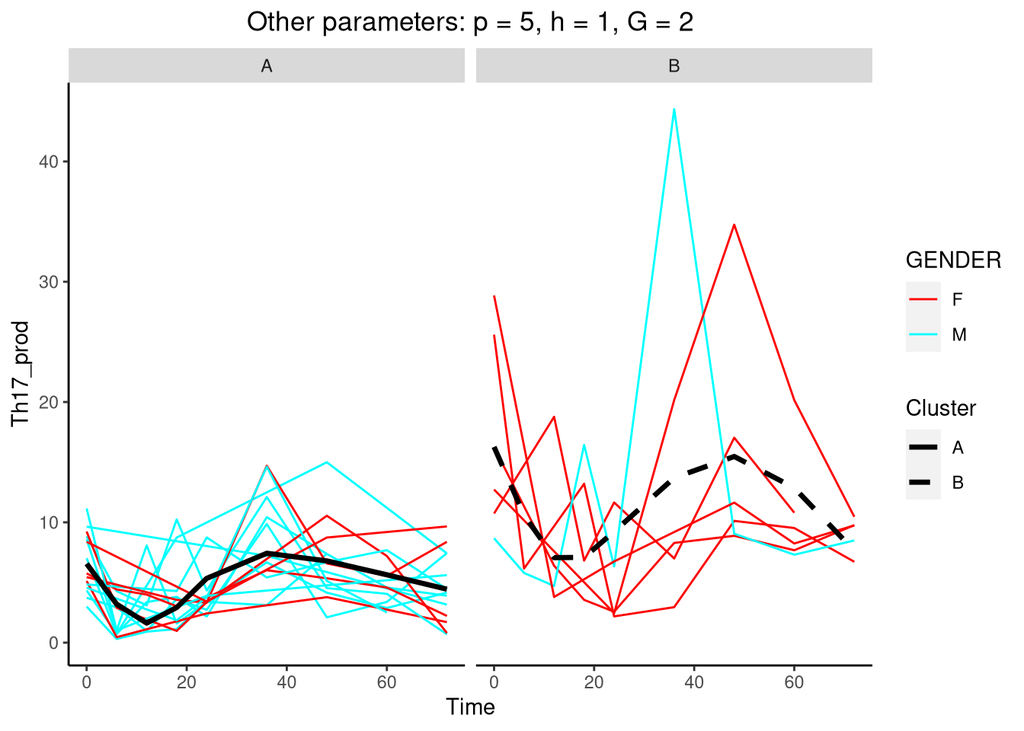

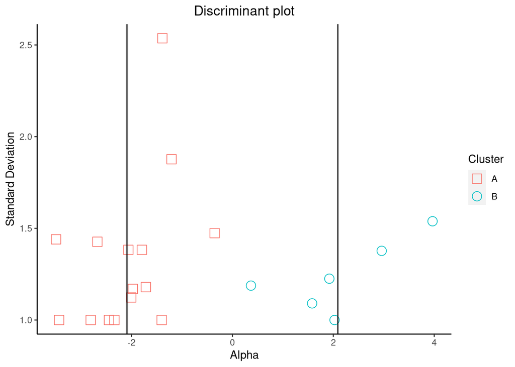

## G = 3##

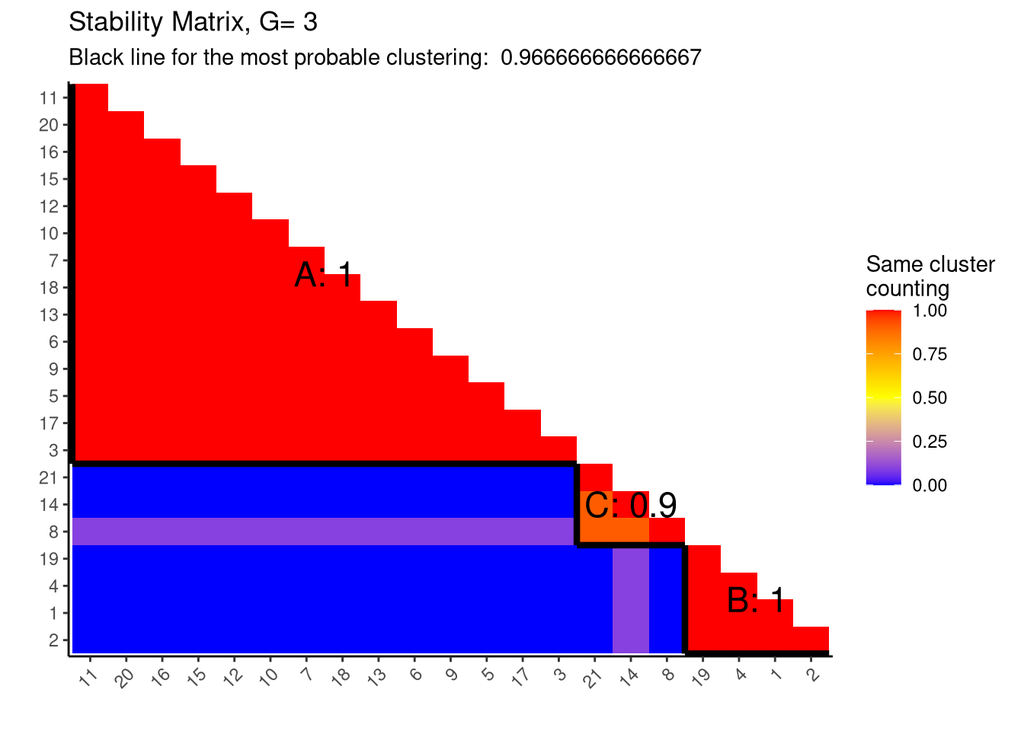

[1] “Cluster 7 has the following errors: All runs have errors, that are the following:ERROR in prediction: number of clusters obtained is different from 7”

S indexes

|  | S | S_1 | S_2 |
| --- | --- | --- | --- |
| Cluster B | 7.848474 | 0.8124809 | 0.1465847 |
| Cluster C | 34.850268 | 2.2915359 | 0.2533604 |
| Cluster A | 4.677704 | 0.3984340 | 0.0551237 |

```
    ######## M indexes ############
```

|  | Cluster B | Cluster C | Cluster A |
| --- | --- | --- | --- |
| Cluster B | 0.00000 | 82.92647 | 45.72283 |
| Cluster C | 82.92647 | 0.00000 | 92.11680 |
| Cluster A | 45.72283 | 92.11680 | 0.00000 |

R indexes

|  | R | R_1 | R_2 |
| --- | --- | --- | --- |
| Cluster B | 0.5148988 | 0.3601834 | 0.4589001 |
| Cluster C | 0.5148988 | 0.5498134 | 0.8065050 |
| Cluster A | 0.4291071 | 0.5498134 | 0.8065050 |

fDB indexes

| fDB | fDB_1 | fDB_2 |
| --- | --- | --- |
| 0.4863016 | 0.4866034 | 0.6906367 |

##############################################################

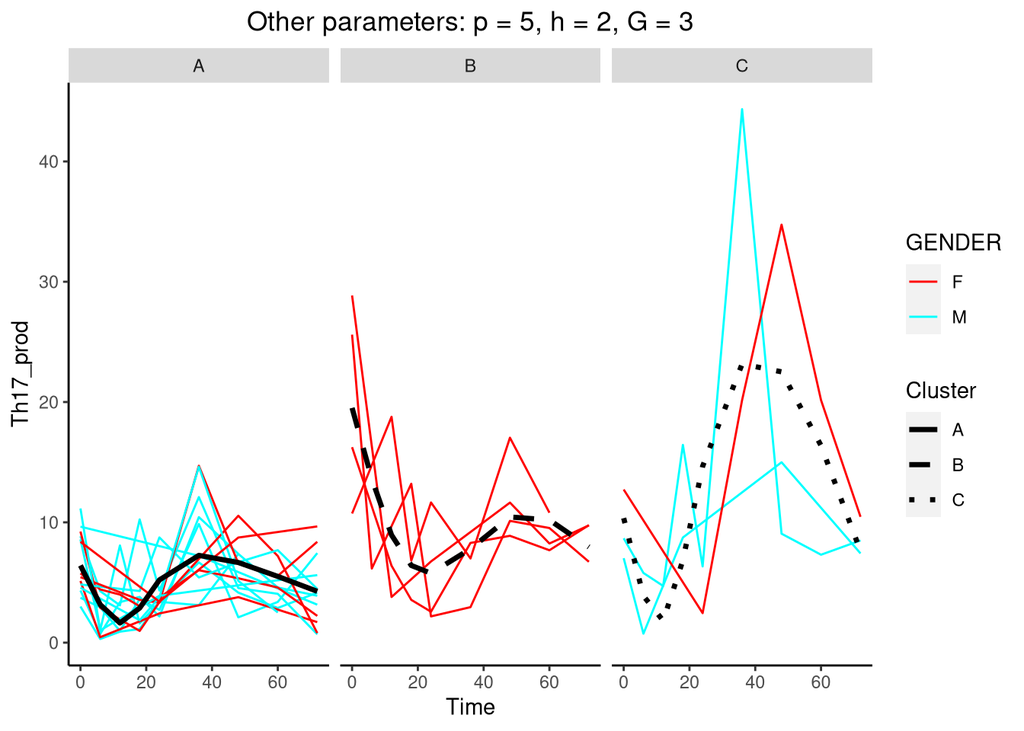

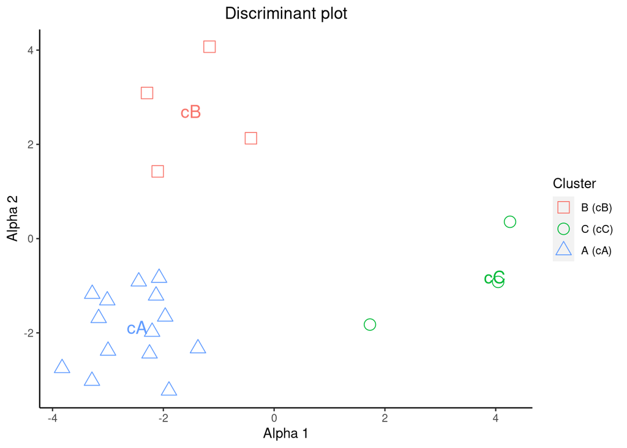

## G = 4##

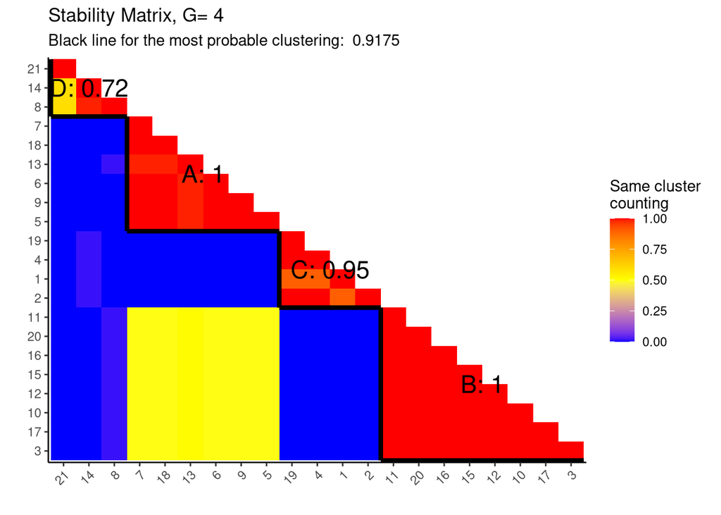

[1] “Cluster 7 has the following errors: All runs have errors, that are the following:ERROR in prediction: number of clusters obtained is different from 7”

S indexes

|  | S | S_1 | S_2 |
| --- | --- | --- | --- |
| Cluster B | 5.617194 | 0.4702633 | 0.0659550 |
| Cluster C | 7.690811 | 0.8041220 | 0.1473834 |
| Cluster A | 2.756515 | 0.2515305 | 0.0322448 |
| Cluster D | 34.272457 | 2.2780038 | 0.2512034 |

```
    ######## M indexes ############
```

|  | Cluster B | Cluster C | Cluster A | Cluster D |
| --- | --- | --- | --- | --- |
| Cluster B | 0.0000000 | 45.75342 | 0.0277717 | 92.03826 |
| Cluster C | 45.7534222 | 0.00000 | 45.7784679 | 83.38645 |
| Cluster A | 0.0277717 | 45.77847 | 0.0000000 | 92.05868 |
| Cluster D | 92.0382581 | 83.38645 | 92.0586834 | 0.00000 |

R indexes

|  | R | R_1 | R_2 |
| --- | --- | --- | --- |
| Cluster B | 301.5190098 | 486.0147143 | 454.9950947 |
| Cluster C | 0.5032384 | 0.3538647 | 0.4555905 |
| Cluster A | 301.5190098 | 486.0147143 | 454.9950947 |
| Cluster D | 0.5032384 | 0.5497602 | 0.8133053 |

fDB indexes

| fDB | fDB_1 | fDB_2 |
| --- | --- | --- |
| 151.0111 | 243.2333 | 227.8148 |

##############################################################

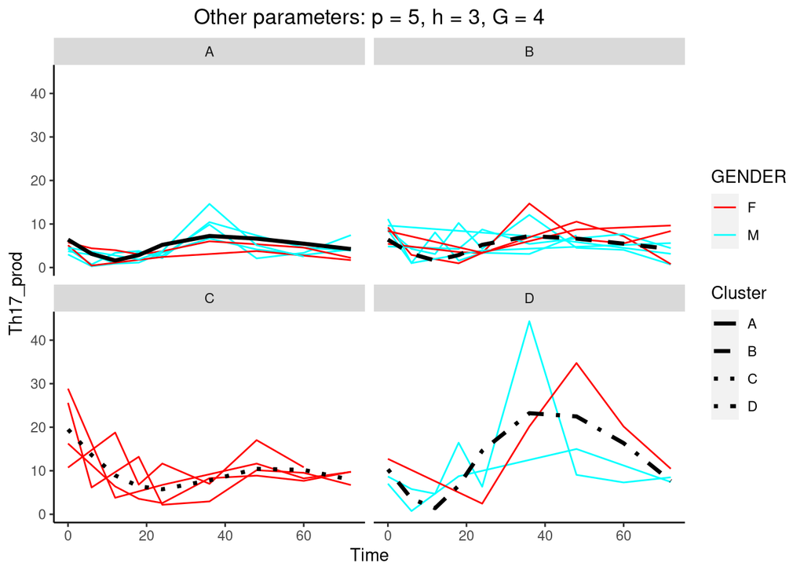

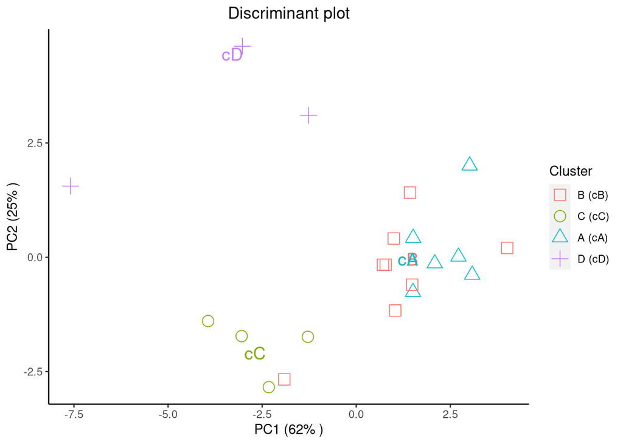

## G = 5##

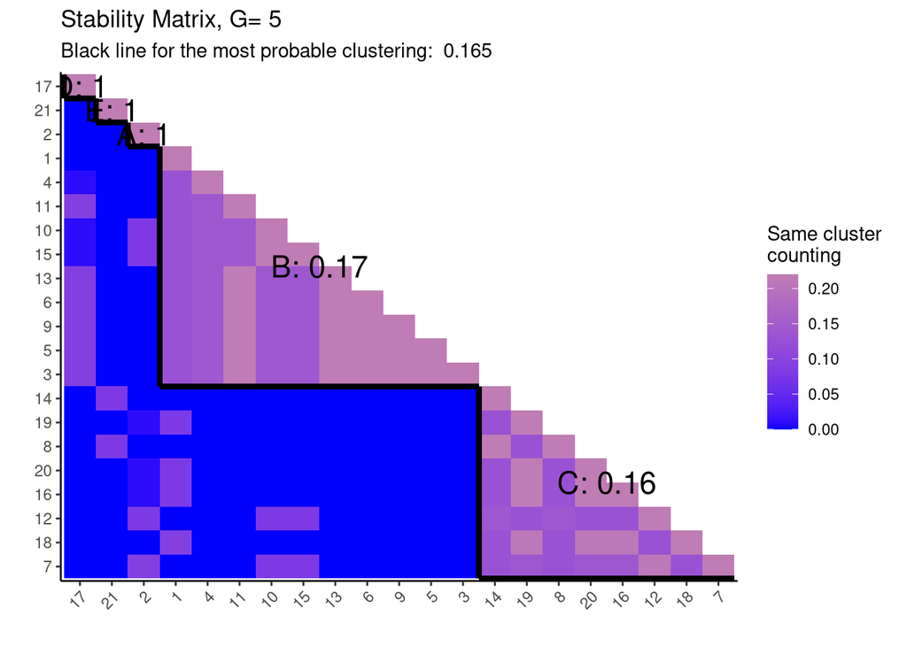

[1] “Cluster 7 has the following errors: All runs have errors, that are the following:ERROR in prediction: number of clusters obtained is different from 7”

S indexes

|  | S | S_1 | S_2 |
| --- | --- | --- | --- |
| Cluster C | 26.739424 | 2.4320760 | 0.3887825 |
| Cluster B | 23.524744 | 1.8563171 | 0.2579599 |
| Cluster A | 14.757873 | 2.0432883 | 0.2808429 |
| Cluster E | 2.595496 | 0.2842432 | 0.0444399 |
| Cluster D | 21.491795 | 0.5956680 | 0.1008153 |

```
    ######## M indexes ############
```

|  | Cluster C | Cluster B | Cluster A | Cluster E | Cluster D |
| --- | --- | --- | --- | --- | --- |
| Cluster C | 0.000000 | 4.4906754 | 2.826515 | 117.4259 | 3.6089322 |
| Cluster B | 4.490675 | 0.0000000 | 1.664160 | 121.9166 | 0.8817432 |
| Cluster A | 2.826515 | 1.6641602 | 0.000000 | 120.2525 | 0.7824170 |
| Cluster E | 117.425945 | 121.9166208 | 120.252461 | 0.0000 | 121.0348777 |
| Cluster D | 3.608932 | 0.8817432 | 0.782417 | 121.0349 | 0.0000000 |

R indexes

|  | R | R_1 | R_2 |
| --- | --- | --- | --- |
| Cluster C | 14.6814342 | 19.7522173 | 45.2342458 |
| Cluster B | 51.0540278 | 34.6908152 | 77.6903508 |
| Cluster A | 46.3303681 | 42.0758303 | 93.1371919 |
| Cluster E | 0.2498163 | 0.2885729 | 0.7044231 |
| Cluster D | 51.0540278 | 42.0758303 | 93.1371919 |

fDB indexes

| fDB | fDB_1 | fDB_2 |
| --- | --- | --- |
| 32.67393 | 27.77665 | 61.98068 |

##############################################################

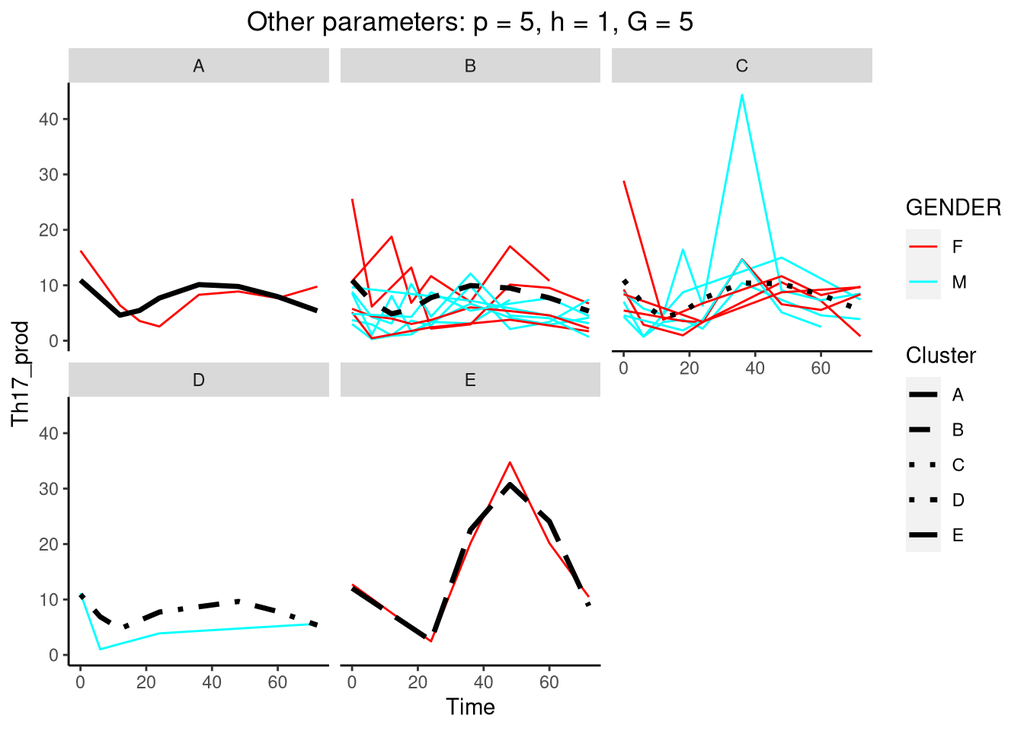

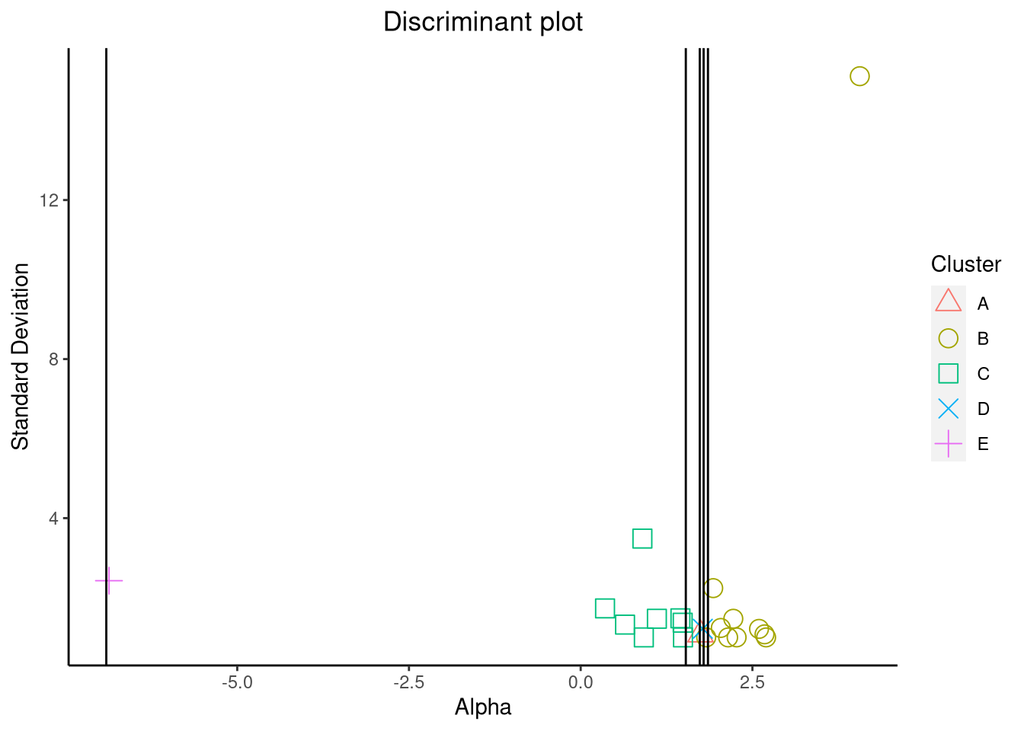